# Practical Machine Learning Assignment

```r
setwd("C:/Users/Ben/Documents/practicalML")
library(caret)
```

```r
library(corrplot)
library(randomForest)
```

## Study summary

Due to the proliferation of ‘quantified self’ devices, it is relatively easy to collect large amounts of personal fittness data. With this data it is relatively trivial to determine how much exercise has been done, but it is a less obvious task to determine whether or not an exercise is being performed correctly. To produce a dataset enabling detection of whether or not an exercise is being performed corrrectly, six participants performed five different exercises using both correct and incorrect form. A complete explanation of the dataset and how it was gathered is available on http://groupware.les.inf.puc-rio.br/har. The R libraries, caret, randomForest and corrplot were used to complete the analysis.

The training dataset is available at: https://d396qusza40orc.cloudfront.net/predmachlearn/pml-training.csv and the testing dataset is available at https://d396qusza40orc.cloudfront.net/predmachlearn/pml-testing.csv.

### loading and munging the data

The data is loaded into R and missing values are designated “NA”.

```r
training  <- read.csv("pml-training.csv",
                      na.strings = c("NA", ""))
testing     <- read.csv("pml-testing.csv",
                     na.strings = c("NA", ""))
```

After the data has been loaded it is good to inspect it. Because the objective of the analysis is to determine whether or not an exercise has been done with proper form some parts of the dataset are not useful.

```r
colnames(training)
```

```
##   [1] "X"                        "user_name"
##   [3] "raw_timestamp_part_1"     "raw_timestamp_part_2"
##   [5] "cvtd_timestamp"           "new_window"
##   [7] "num_window"               "roll_belt"
##   [9] "pitch_belt"               "yaw_belt"
##  [11] "total_accel_belt"         "kurtosis_roll_belt"
##  [13] "kurtosis_picth_belt"      "kurtosis_yaw_belt"
##  [15] "skewness_roll_belt"       "skewness_roll_belt.1"
##  [17] "skewness_yaw_belt"        "max_roll_belt"
##  [19] "max_picth_belt"           "max_yaw_belt"
##  [21] "min_roll_belt"            "min_pitch_belt"
##  [23] "min_yaw_belt"             "amplitude_roll_belt"
##  [25] "amplitude_pitch_belt"     "amplitude_yaw_belt"
##  [27] "var_total_accel_belt"     "avg_roll_belt"
##  [29] "stddev_roll_belt"         "var_roll_belt"
```

[output cut: 65 more lines]

```r
training <- subset(training,
                   select = -c(1:6))
testing  <- subset(testing,
                   select = -c(1:6))
```

```r
trainingSum <- colSums(is.na(training))
trainingSumZero <- (trainingSum == 0)
trainingNAMunge <- training[, (colSums(is.na(training)) == 0)]
testingNAMunge <- testing[, (colSums(is.na(training)) == 0)]
```

### Partitioning the data

Now that the data has been formatted in such a way that it is parsable by various analytic functions, it is appropriate to partition toe training set into testing and test validation sets to prevent overfitting.

```r
processedTraining <- createDataPartition(y = trainingNAMunge$classe,
                                         p = 0.6,
                                         list = FALSE)
partitionedTraining <- trainingNAMunge[processedTraining, ]
partitionedTrainingTest <- trainingNAMunge[-processedTraining, ]
```

### Correlation matrix

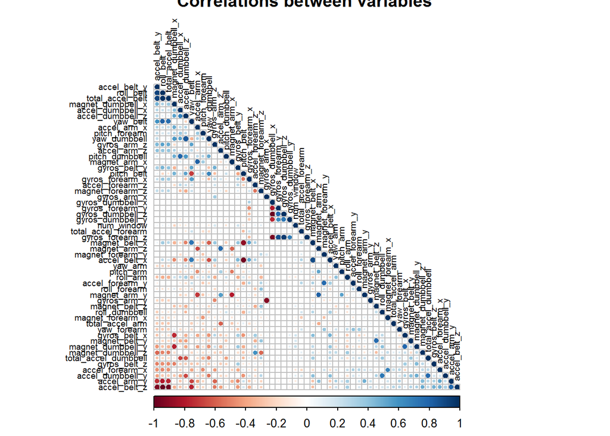

```r
correlations <- cor(partitionedTraining[, -54])
corrplot( correlations,
          order = "FPC",
          method = "circle",
          type = "lower",
          tl.cex = 0.6,
          tl.col = "black",
          title = "Correlations between variables")
```

### Preprocessing and prediction

```r
preProcessedTraining <- preProcess(partitionedTraining[, -54],
                                   method = "pca",
                                   thresh = 0.99)
trainingPrediction <- predict(preProcessedTraining,
                              partitionedTraining[, -54])
testValidation <- predict(preProcessedTraining,
                          partitionedTraining[, -54])
```

To employ the variables selected by PCA in the matrix above, the preprocessing function is used on the dataset with the ‘classe’ variable removed. The prediction function can then be used.

### Training a random forest model

```r
randomForestModel <- train(  partitionedTraining$classe ~ .,
                    method = "rf",
                    data = trainingPrediction,
                    trControl = trainControl(method = "cv",
                    number = 4),
                    importance = TRUE)
```

As random forests are a generally good predictor, and deal well with both linear and nonlinearly correlated variables one was chosen to train a model on. A random forest takes a long time to run, and it can potentially overfit a model- so a smaller subset of data was used to train on.

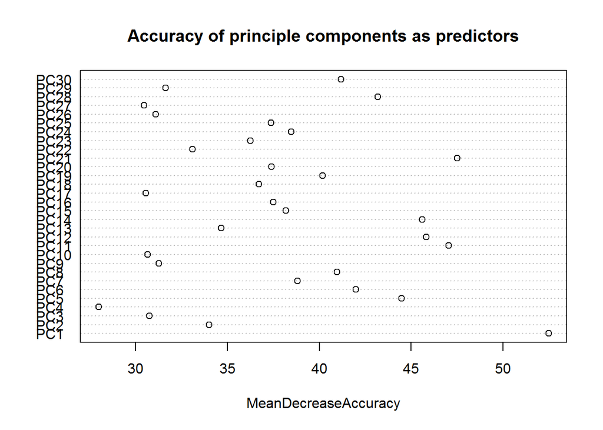

```r
varImpPlot(randomForestModel$finalModel,
        sort = FALSE,
            type = 1,
main = "Accuracy of principle components as predictors")
```

```r
validationRandomForest <- predict(randomForestModel, testValidation)
confusionMatrixOut <- confusionMatrix(partitionedTraining$classe, validationRandomForest)
confusionMatrixOut$table
```

```
##           Reference
## Prediction    A    B    C    D    E
##          A 3348    0    0    0    0
##          B    0 2279    0    0    0
##          C    0    0 2054    0    0
##          D    0    0    0 1930    0
##          E    0    0    0    0 2165
```

### The final model

```r
predictiveAccuracy <- postResample(partitionedTraining$classe, validationRandomForest)
randomForestAccuracy <- predictiveAccuracy[[1]]
randomForestAccuracy
```

```
## [1] 1
```

The accuracy of the model.

```r
testpredictiveModel <- predict(preProcessedTraining, testingNAMunge[,-54])
prediction <- predict( ,testpredictiveModel)
```

## Conclusion

B A B A A E D B A A B C B A E E A B B B

The character vector above was submitted to the website for grading, and successfully predicted nineteen out of twenty of the results. As such, the following method had a 95% accuracy.